# EDLD653_midterm

Author

Cheyna

## Library Packages

```r
library(glue)
library(rio)
library(tidyverse)
library(purrr)
library(janitor)
library(glue)
library(ggtext)
```

# Midterm Test

Please work independently on this test, NOT with a partner or group. If you include any content generated GenAI, you must cite it. See example in syllabus.

Please set embed-resources: true in the YAML header of quarto document so that your html output file can be displayed properly in a browser.

Please submit your qmd and html documents.

# Setup

This work should all be housed in a GitHub repo.

Loading the data takes a minute, so I would suggest you do it once and cache it. This just means including cache: true in your YAML.

The problem with caching is that sometimes results of a later chunk depend upon earlier ones and things can get out of sync. If you make a change and it doesn’t have the result you expect, try clearing the cache and rendering again. To clear the cache, go to the Terminal in RStudio and enter quarto render –cache-refresh

If this is confusing, don’t worry about it, just ignore this part and don’t use caching. It will just take a little longer to render your file each time you render.

I would also recommend not tracking the cache files. This means adding the cache folder to your .gitignore file. If you initialized your repo with the R and a .gitignore file this is actually already taken care of for you. If not, add /*_cache/ to your .gitignore.

# Part A: Data (20 Points)

The following function downloads data from the Oregon Department of education website on the number of students who scored in each performance category on the statewide assessment by race/ethnicity for every school in the state. It takes one argument, year, which must be a two digit integer from 15 to 18 (representing the 2014-15 to 2017-18 school years). It actually won’t work on later years because the file structure changed and I wanted to keep the function simple.

**NOTE:** This function uses the glue() function from the package of the same name. If you do not already have this package installed, please first install it with install.packages(“glue”). It also uses {rio} for the import, which you should already have installed, but if not, install that first too.

## Download Data

```r
download_file <- function(year) {
  link <- glue::glue("https://www.oregon.gov/ode/educator-resources/assessment/TestResults20{year}/pagr_schools_ela_raceethnicity_{year-1}{year}.xlsx")
  rio::import(link, setclass = "tibble", na = c("-", "--", "*"))
}
```

## A1. (10 Points)

Use the function above to download all of the data from the 2014-15 to 2017-18 school years and bind it into a single data frame, using a single function (i.e., one line of code). Note, this may take a minute or two to run, depending on your Internet speed.

```r
all_data <- map_dfr(15:18, download_file) %>% #download and make df at same time
  clean_names #clean names obvi
```

Conduct some basic data cleaning to make your data file look like the following.

- Filter for only student groups coded as “White” or “Hispanic/Latino”.
- Select variables related to the number of students in each of the levels (1 through 4), and not percentages or combined levels.
- Remove any row that has missing data in any of the n variables

```r
filtered_data <- all_data %>%
  filter(student_group %in% c("White", "Hispanic/Latino")) %>% #Filter for only student groups coded as "White" or "Hispanic/Latino".
  select(-percent_level_1, -percent_level_2, -percent_level_3, -percent_level_4, -percent_proficient_level_3_or_4, -number_proficient_level_3_or_4, -number_proficient, -number_of_participants)

filtered_data <- filtered_data %>%
  pivot_longer(cols = starts_with("number"),
               names_to = "level",
               values_to = "n",
               names_prefix = ("number_")) %>%
               drop_na()
```

## A2. (10 Points)

- Sum the n across grades and school for each district within each academic year, student group, and level.
- Calculate the number of schools (unique schools listed) for each district.
- Also move your data to a wider format where the student groups become new columns, filled by the district n.
- Remove districts that did not report numbers for one or both student groups (i.e., drop missing data from the new columns).

Your data frame should look like the below

```r
summary_stats <- filtered_data %>%
  group_by(district) %>%
  mutate(n_school = n_distinct(school)) %>%
  group_by(academic_year, district, student_group, level, n_school) %>%
  summarize(n_students = sum(n)) %>%
    pivot_wider(names_from = student_group,
                values_from = n_students) %>%
  clean_names() %>%
  drop_na()
```

```
`summarise()` has regrouped the output.
ℹ Summaries were computed grouped by academic_year, district, student_group,
  level, and n_school.
ℹ Output is grouped by academic_year, district, student_group, and level.
ℹ Use `summarise(.groups = "drop_last")` to silence this message.
ℹ Use `summarise(.by = c(academic_year, district, student_group, level,
  n_school))` for per-operation grouping (`?dplyr::dplyr_by`) instead.
```

# Part B: Achievement disparities (50 points)

Please install the {gapr} package using the following code:

```r
remotes::install_github("datalorax/gapr")
```

[output not shown]

```
Downloading GitHub repo dpc10ster/RJafroc@662c4bf3bcd725d8fa148a3e7db69168294ae57e
```

[output not shown]

[output not shown]

```
Running `R CMD build`...
```

[output not shown]

[output not shown]

```
Skipping install of 'RJafroc' from a github remote, the SHA1 (662c4bf3) has not changed since last install.
  Use `force = TRUE` to force installation
```

```
Running `R CMD build`...
```

[output not shown]

The {gapr} package includes a function, estimate_v(), which estimates the average difference between two distributions in terms of an effect size when the only data available are counts within bins (for more information, see Ho & Reardon, 2012). The nice thing about this approach is that we’re able to obtain the effect size of average differences in achievement between two groups of students as if we had the full, student level data even though we just have counts within bins (performance levels).

The estimate_v() function takes 3 arguments in the following order:

1. the data frame including the counts for each group
2. a character string stating the name of the column with the counts for the reference group
3. a character string stating the name of the column with the counts for the focal group

To estimate the average achievement difference between students coded Hispanic/Latino versus White for the first school district in the first year in our data, we would run the following

```r
library(gapr)

summary_stats[1:4, ] |> # data source - just first four rows for first district
  estimate_v("white", "hispanic_latino") # columns for reference/focal groups
```

```
        auc          v       v_se
1 0.2824054 -0.8141778 0.07283486
```

We can see that students coded Hispanic/Latino scored, on average, about 0.81 standard deviations below students coded White within this school district for this year.

## B1. (15 Points)

Estimate the average achievement differences in terms of an effect size for every school district in the state that reported data on both student groups (i.e., using the data we created above), for each academic year. Conduct this analysis twice, once using group_by() |> nest() and map() and once using nest_by() |> summarize().

Note, on my computer these took about 1 minute per analysis. It will likely take a bit longer for you, but shouldn’t take too long. You may get a warning. Just go ahead and ignore that for now.

# using group_by() |> nest() and map()

```r
effect_sizes_nested_option1 <- summary_stats %>% #new df
  group_by(district, academic_year) %>% # every school district in the state for each academic year
  nest() %>%
  mutate(effect_size_1 =
           map(data, ~ estimate_v(.x, "white", "hispanic_latino")))
```

[output not shown]

# using nest_by() |> summarize().

```r
effect_sizes_nested_option2 <- summary_stats %>% #new df
  ungroup() %>%
  nest_by(district, academic_year) %>% # every school district in the state for each academic year
  summarize(effect_size_2 = list(estimate_v(data, "white", "hispanic_latino")))
```

```
`summarise()` has converted the output from a rowwise data frame to a grouped
data frame.
ℹ Summaries were computed rowwise.
ℹ Output is grouped by district and academic_year.
ℹ Use `summarise(.groups = "keep")` to silence this message.
```

## B2. (10 Points)

Reproduce the following plot to confirm that the estimates are equivalent across methods.

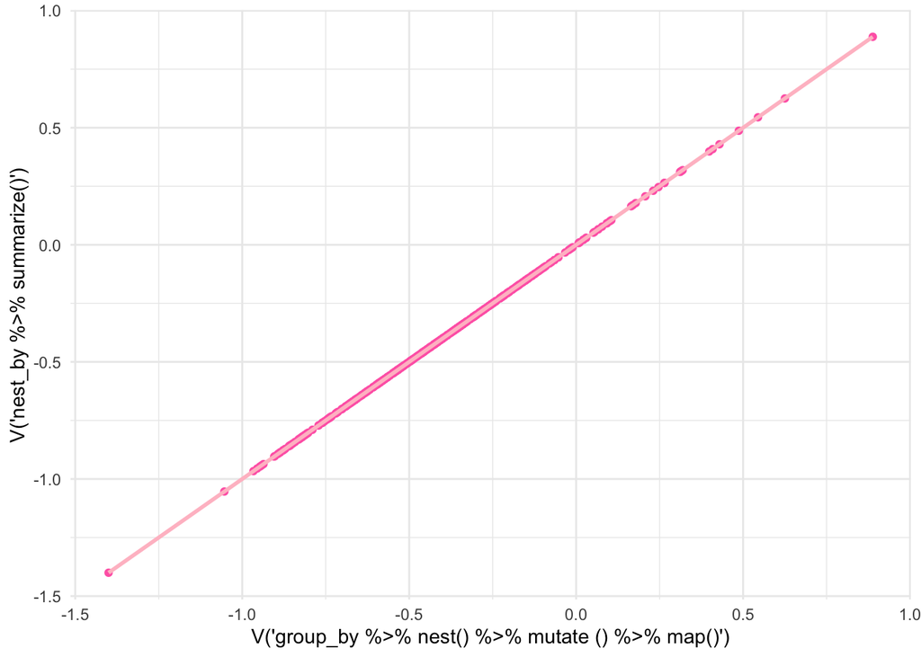

```r
plot_data <- left_join(effect_sizes_nested_option1, effect_sizes_nested_option2, by = c("academic_year", "district"))

clean_data <- plot_data %>%
  unnest(effect_size_1) %>% # get data out of its evil form
  select(c(district, academic_year, data, v, effect_size_2, v_se))
  colnames(clean_data)[colnames(clean_data) == "v"] <- "option1" #rename v so i can have v twice
  colnames(clean_data)[colnames(clean_data) == "v_se"] <- "option1_se" #rename v so i can have v twice

clean_data <- clean_data %>%
  unnest(effect_size_2) %>% # get data out of its evil form again
  select(c(-auc))
  colnames(clean_data)[colnames(clean_data) == "v"] <- "option2" #rename v so i can have v twice
  colnames(clean_data)[colnames(clean_data) == "v_se"] <- "option2_se" #rename v so i can have v twice

plot <- clean_data %>%
  ggplot(aes(x = option1, y = option2))+
  geom_point(color = "hotpink")+
  geom_smooth(method = "lm", color = "pink")+
  labs(x = "V('group_by %>% nest() %>% mutate () %>% map()')",
       y = "V('nest_by %>% summarize()')")+
  theme_minimal()

plot
```

## B3. (15 points)

The plot below shows the achievement difference estimates for one school district across years. Produce a similar plot to the below for each of the first 100 school districts. Once you’ve created all the plots, reproduce them again using an alternative method. Make sure you don’t miss the caption noting the number of schools in the district.

**HINT**: You need to select unique districts. You may want to try something like the following:

```r
dists <- unique(clean_data$district)[1:100]

#model_list_object |>
#  filter(district %in% dists)

cleaner_data <- clean_data  %>%  #filtering my df :)
  filter(district %in% dists)
```

### Achievement difference estimates for one school district across years (Version 1)

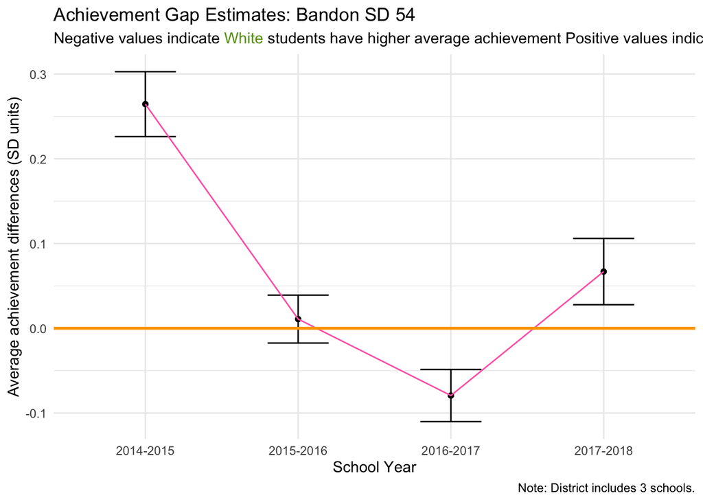

```r
plots <- cleaner_data %>%
  group_by(district) %>%
  nest() %>%
  mutate(n_school = map_int(data, ~unique(.x$data[[1]]$n_school[[1]])),
        plot = pmap(list(data, district, n_school), \(.x, .y, .z) .x %>%
        ggplot(aes(x = academic_year, y = option1, group = 1)) +
        geom_errorbar(aes(ymin = option1 - option1_se, ymax = option1 + option1_se), width = .4)+
        geom_point()+
        geom_line(color = "hotpink")+
        geom_hline(yintercept = 0, color = "orange", linewidth = 1)+
        labs(
          title = glue("Achievement Gap Estimates: {.y}"),
          subtitle = paste(
            "Negative values indicate <span style='color:#679c0c'>White</span> students have higher average achievement",
            "Positive values indicate <span style='color:#679c0c'>Hispanic/Latino</span> students have higher achievement",sep = "\n"),
          x = "School Year",
          y = "Average achievement differences (SD units)",
          caption = glue("Note: District includes {.z} schools."))+
        theme_minimal()+
        theme(plot.subtitle = element_markdown())
)
)

plots$plot[[7]]
```

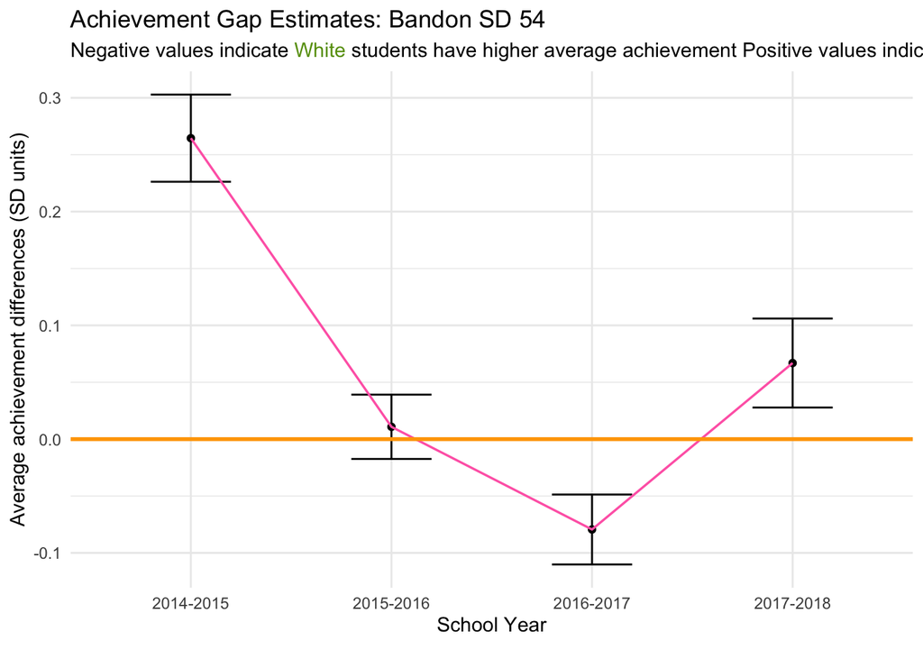

```r
# school_data <- cleaner_data %>%
#   unnest(data) %>% # get data out of its evil form
#   select(c(n_school, district, academic_year, option1, option1_se))

version2_plots <- cleaner_data %>%
  ungroup() %>%
  nest_by(district) %>%
    mutate(
      plots = list(
        ggplot(data, aes(x = academic_year, y = option1)) +
          geom_errorbar(aes(ymin = option1 - option1_se,
                          ymax = option1 + option1_se), width = .4)+
        geom_point()+
        geom_line(aes(group = 1), color = "hotpink", linewidth = .6)+
        geom_hline(yintercept = 0, color = "orange", linewidth = 1)+
          labs(
          title = glue("Achievement Gap Estimates: {district} "),
          subtitle = paste(
            "Negative values indicate <span style='color:#679c0c'>White</span> students have higher average achievement",
            "Positive values indicate <span style='color:#679c0c'>Hispanic/Latino</span> students have higher achievement",sep ="\n"),
          x = "School Year",
          y = "Average achievement differences (SD units)",
          caption = glue("District includes {data$n_school} schools"))+
  theme_minimal()+
  theme(plot.subtitle = element_markdown())))
version2_plots$plots[[7]]
```

## B4. (10 points)

Save the plots into a “plots” directory. Make sure the file names are meaningful.

**HINTS:** You don’t have to use a loop to create the file names (maybe give {glue} a try? Otherwise paste or paste0 will work fine). When working with the code, limit the number of plots you’re saving to, say, the first five to make sure it works before running it on all plots.

```r
fs::dir_create(here::here("plots"))

files <- str_replace_all(
  tolower(plots$district),
  " ",
  "-"
)
paths <- here::here("plots", glue("{files}.png"))
paths
```

```
  [1] "/Users/cheyna/Library/CloudStorage/Dropbox-UniversityofOregon/Cheyna Warner/Personal/Coursework/Data Science Specalization/EDLD 653/EDLD653_midterm/plots/adrian-sd-61.png"
  [2] "/Users/cheyna/Library/CloudStorage/Dropbox-UniversityofOregon/Cheyna Warner/Personal/Coursework/Data Science Specalization/EDLD 653/EDLD653_midterm/plots/amity-sd-4j.png"
  [3] "/Users/cheyna/Library/CloudStorage/Dropbox-UniversityofOregon/Cheyna Warner/Personal/Coursework/Data Science Specalization/EDLD 653/EDLD653_midterm/plots/ashland-sd-5.png"
  [4] "/Users/cheyna/Library/CloudStorage/Dropbox-UniversityofOregon/Cheyna Warner/Personal/Coursework/Data Science Specalization/EDLD 653/EDLD653_midterm/plots/astoria-sd-1.png"
  [5] "/Users/cheyna/Library/CloudStorage/Dropbox-UniversityofOregon/Cheyna Warner/Personal/Coursework/Data Science Specalization/EDLD 653/EDLD653_midterm/plots/athena-weston-sd-29rj.png"
  [6] "/Users/cheyna/Library/CloudStorage/Dropbox-UniversityofOregon/Cheyna Warner/Personal/Coursework/Data Science Specalization/EDLD 653/EDLD653_midterm/plots/baker-sd-5j.png"
  [7] "/Users/cheyna/Library/CloudStorage/Dropbox-UniversityofOregon/Cheyna Warner/Personal/Coursework/Data Science Specalization/EDLD 653/EDLD653_midterm/plots/bandon-sd-54.png"
  [8] "/Users/cheyna/Library/CloudStorage/Dropbox-UniversityofOregon/Cheyna Warner/Personal/Coursework/Data Science Specalization/EDLD 653/EDLD653_midterm/plots/banks-sd-13.png"
  [9] "/Users/cheyna/Library/CloudStorage/Dropbox-UniversityofOregon/Cheyna Warner/Personal/Coursework/Data Science Specalization/EDLD 653/EDLD653_midterm/plots/beaverton-sd-48j.png"
 [10] "/Users/cheyna/Library/CloudStorage/Dropbox-UniversityofOregon/Cheyna Warner/Personal/Coursework/Data Science Specalization/EDLD 653/EDLD653_midterm/plots/bend-lapine-administrative-sd-1.png"
 [11] "/Users/cheyna/Library/CloudStorage/Dropbox-UniversityofOregon/Cheyna Warner/Personal/Coursework/Data Science Specalization/EDLD 653/EDLD653_midterm/plots/bethel-sd-52.png"
 [12] "/Users/cheyna/Library/CloudStorage/Dropbox-UniversityofOregon/Cheyna Warner/Personal/Coursework/Data Science Specalization/EDLD 653/EDLD653_midterm/plots/brookings-harbor-sd-17c.png"
 [13] "/Users/cheyna/Library/CloudStorage/Dropbox-UniversityofOregon/Cheyna Warner/Personal/Coursework/Data Science Specalization/EDLD 653/EDLD653_midterm/plots/canby-sd-86.png"
 [14] "/Users/cheyna/Library/CloudStorage/Dropbox-UniversityofOregon/Cheyna Warner/Personal/Coursework/Data Science Specalization/EDLD 653/EDLD653_midterm/plots/cascade-sd-5.png"
 [15] "/Users/cheyna/Library/CloudStorage/Dropbox-UniversityofOregon/Cheyna Warner/Personal/Coursework/Data Science Specalization/EDLD 653/EDLD653_midterm/plots/centennial-sd-28j.png"
```

[output cut: 85 more lines]

```r
plots %>%
  ungroup() %>%
  mutate(path = paths) %>%
  rowwise() %>%
  summarize(
    ggsave(path, plot,
      width = 9.5,
      height = 6.5,
      dpi = 500
    )
  )
```

```
`geom_line()`: Each group consists of only one observation.
ℹ Do you need to adjust the group aesthetic?
```

```
# A tibble: 100 × 1
   `ggsave(path, plot, width = 9.5, height = 6.5, dpi = 500)`
   <chr>
 1 /Users/cheyna/Library/CloudStorage/Dropbox-UniversityofOregon/Cheyna Warner/…
 2 /Users/cheyna/Library/CloudStorage/Dropbox-UniversityofOregon/Cheyna Warner/…
 3 /Users/cheyna/Library/CloudStorage/Dropbox-UniversityofOregon/Cheyna Warner/…
 4 /Users/cheyna/Library/CloudStorage/Dropbox-UniversityofOregon/Cheyna Warner/…
 5 /Users/cheyna/Library/CloudStorage/Dropbox-UniversityofOregon/Cheyna Warner/…
 6 /Users/cheyna/Library/CloudStorage/Dropbox-UniversityofOregon/Cheyna Warner/…
 7 /Users/cheyna/Library/CloudStorage/Dropbox-UniversityofOregon/Cheyna Warner/…
 8 /Users/cheyna/Library/CloudStorage/Dropbox-UniversityofOregon/Cheyna Warner/…
 9 /Users/cheyna/Library/CloudStorage/Dropbox-UniversityofOregon/Cheyna Warner/…
10 /Users/cheyna/Library/CloudStorage/Dropbox-UniversityofOregon/Cheyna Warner/…
# ℹ 90 more rows
```